# Inflammatron

```python
#import libraries
import pandas as pd
import numpy as np
import matplotlib.pyplot as plt
import seaborn as sns
```

```python
df=pd.read_csv(r'arthritis-factor-measurements-matrix-zeros-unixtime (1).csv')
df.head()
```

|  | Date | Arthritis (/5) | Biking (min) | Cold Shower (min) | Light Therapy (min) | Meditation (min) | TDCS (min) | Kratomystic Bali Green Kratom (g) | L-Glutamine by Body Fortress (g) | Omega 3 Fish Oil Platinum (g) | ... | Spending on Twinlab BCAA Fuel Fruit Punch Powder ($) | Spending on VantaKool Digital PH ($) | Spending on Vitamin D-3, 1, 000 IU, 360 Softgels by Now Foods (Pack of 3) ($) | Spending on Vitamins ($) | Spending on Vitamins & Dietary Supplements ($) | Clobetasol Propionate (sprays) | Flonase (sprays) | Grapefruit Seed Extract (GSE) (drops) | Vitamin D3 (IU) | Body Butter (qt) |
| --- | --- | --- | --- | --- | --- | --- | --- | --- | --- | --- | --- | --- | --- | --- | --- | --- | --- | --- | --- | --- | --- |
| 0 | 1333670400 | 3.28 | 0 | 0 | 0 | 0 | 0 | 0 | 0 | 0.0 | ... | 0 | 0.0 | 0 | 0.0 | 0.0 | 0 | 0 | 0 | 0 | 0 |
| 1 | 1333756800 | 3.76 | 0 | 0 | 0 | 0 | 0 | 0 | 0 | 0.0 | ... | 0 | 0.0 | 0 | 0.0 | 0.0 | 0 | 0 | 0 | 0 | 0 |
| 2 | 1333843200 | NaN | 0 | 0 | 0 | 0 | 0 | 0 | 0 | 0.0 | ... | 0 | 0.0 | 0 | 0.0 | 0.0 | 0 | 0 | 0 | 0 | 0 |
| 3 | 1333929600 | NaN | 0 | 0 | 0 | 0 | 0 | 0 | 0 | 0.0 | ... | 0 | 0.0 | 0 | 0.0 | 0.0 | 0 | 0 | 0 | 0 | 0 |
| 4 | 1334016000 | NaN | 0 | 0 | 0 | 0 | 0 | 0 | 0 | 0.0 | ... | 0 | 0.0 | 0 | 0.0 | 0.0 | 0 | 0 | 0 | 0 | 0 |

5 rows × 374 columns

```python
df.rename(columns={'Arthritis (/5)': 'Arthritis_Severity'}, inplace=True)
```

```python
df.dtypes
```

```
Date                                       int64
Arthritis_Severity                       float64
Biking (min)                               int64
Cold Shower (min)                          int64
Light Therapy (min)                        int64
                                          ...
Clobetasol Propionate (sprays)             int64
Flonase (sprays)                           int64
Grapefruit Seed Extract (GSE) (drops)      int64
Vitamin D3 (IU)                            int64
Body Butter (qt)                           int64
Length: 374, dtype: object
```

```python
df['Arthritis_Severity'] = pd.to_numeric(df['Arthritis_Severity'], errors='coerce')
df = df.replace(np.nan, 0, regex=True)
print(df)
print(df.dtypes)
```

```
            Date  Arthritis_Severity  Biking (min)  Cold Shower (min)  \
0     1333670400                3.28             0                  0
1     1333756800                3.76             0                  0
2     1333843200                0.00             0                  0
3     1333929600                0.00             0                  0
4     1334016000                0.00             0                  0
...          ...                 ...           ...                ...
3441  1630972800                0.00             0                  0
3442  1631059200                0.00             0                  0
3443  1631145600                0.00             0                  0
3444  1631232000                0.00             0                  0
3445  1631318400                0.00             0                  0

      Light Therapy (min)  Meditation (min)  TDCS (min)  \
0                       0                 0           0
```

[output cut: 141 more lines]

```python
X = df.iloc[:, :-1].values
print(X)
```

```
[[1.3336704e+09 3.2800000e+00 0.0000000e+00 ... 0.0000000e+00
  0.0000000e+00 0.0000000e+00]
 [1.3337568e+09 3.7600000e+00 0.0000000e+00 ... 0.0000000e+00
  0.0000000e+00 0.0000000e+00]
 [1.3338432e+09 0.0000000e+00 0.0000000e+00 ... 0.0000000e+00
  0.0000000e+00 0.0000000e+00]
 ...
 [1.6311456e+09 0.0000000e+00 0.0000000e+00 ... 0.0000000e+00
  0.0000000e+00 0.0000000e+00]
 [1.6312320e+09 0.0000000e+00 0.0000000e+00 ... 0.0000000e+00
  0.0000000e+00 0.0000000e+00]
 [1.6313184e+09 0.0000000e+00 0.0000000e+00 ... 0.0000000e+00
  0.0000000e+00 0.0000000e+00]]
```

```python
Y = df.iloc[:, -1].values
print(Y)
```

```
[0 0 0 ... 0 0 0]
```

```python
# split into train and test sets
from sklearn.model_selection import train_test_split
X_train, X_test, Y_train, Y_test = train_test_split(X, Y, test_size=0.33, random_state=1)
```

```python
print('Train', X_train.shape, Y_train.shape)
print('Test', X_test.shape, Y_test.shape)
```

```
Train (2308, 373) (2308,)
Test (1138, 373) (1138,)
```

```python
# example of anova f-test feature selection for numerical data
from pandas import read_csv
from sklearn.model_selection import train_test_split
from sklearn.feature_selection import SelectKBest
from sklearn.feature_selection import f_classif
from matplotlib import pyplot
```

```python
# feature selection
def select_features(X_train, Y_train, X_test):
    #configure to select all features
    fs = SelectKBest(score_func=f_classif, k='all')
    #learn relationship from training data
    fs.fit(X_train, Y_train)
    # transform train input data
    X_train_fs = fs.transform(X_train)
    # transform test input data
    X_test_fs = fs.transform(X_test)
    return X_train_fs, X_test_fs, fs
```

```
Feature 0: 0.186842
Feature 1: 0.100339
Feature 2: 0.002605
Feature 3: 0.058800
Feature 4: 0.000433
Feature 5: 0.148769
Feature 6: 0.001109
Feature 7: 0.015838
Feature 8: 0.151684
Feature 9: 6.461688
Feature 10: 0.000433
Feature 11: 0.000433
Feature 12: 0.008114
Feature 13: 0.017412
Feature 14: 0.000780
Feature 15: 0.439015
Feature 16: 0.271903
Feature 17: 1.079392
Feature 18: 0.605983
Feature 19: 0.209867
Feature 20: 1.241895
Feature 21: 0.340787
Feature 22: 0.326548
Feature 23: 0.000433
Feature 24: 0.178899
Feature 25: 0.070743
Feature 26: 0.078608
Feature 27: 0.864790
Feature 28: 0.003873
Feature 29: 0.175716
Feature 30: 0.422880
Feature 31: 2.025458
Feature 32: 2.123633
Feature 33: 0.083196
Feature 34: 0.083196
Feature 35: 0.001735
Feature 36: 0.001288
Feature 37: 0.015014
Feature 38: 0.000867
Feature 39: 0.003041
```

[output cut: 318 more lines]

```
Feature 358: 0.002091
Feature 359: nan
Feature 360: 0.004089
Feature 361: 0.000867
Feature 362: 0.001134
Feature 363: 0.000780
Feature 364: 0.000433
Feature 365: nan
Feature 366: 0.000433
Feature 367: 0.001955
Feature 368: 0.006598
Feature 369: 0.000433
Feature 370: 0.020160
Feature 371: 0.016733
Feature 372: 12.680406
```

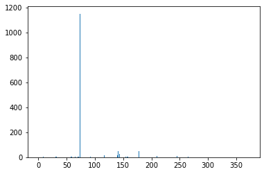

```python
# split into train and test sets
X_train, X_test, Y_train, Y_test = train_test_split(X, Y, test_size=0.33, random_state=1)
# feature selection
X_train_fs, X_test_fs, fs = select_features(X_train, Y_train, X_test)
# what are scores for the features
for i in range(len(fs.scores_)):
    print('Feature %d: %f' % (i, fs.scores_[i]))
# plot the scores
pyplot.bar([i for i in range(len(fs.scores_))], fs.scores_)
pyplot.show()
```

```python
#df.drop(df.columns[[1, 3]], axis=1)
```

Modeling With Selected Features

we will evaluate a Logistic Regression model with all features compared to a model built from features selected by ANOVA f-test

Model Built Using All Features

As a first step, we will evaluate a LogisticRegression model using all the available features.

The model is fit on the training dataset and evaluated on the test dataset.

```python
from pandas import read_csv
from sklearn.model_selection import train_test_split
from sklearn.linear_model import LogisticRegression
from sklearn.metrics import accuracy_score
```

```python
# split into train and test sets
X_train, X_test, Y_train, Y_test = train_test_split(X, Y, test_size=0.33, random_state=1)
# fit the model
model = LogisticRegression(solver='liblinear')
model.fit(X_train, Y_train)
# evaluate the model
yhat = model.predict(X_test)
# evaluate predictions
accuracy = accuracy_score(Y_test, yhat)
print('Accuracy: %.2f' % (accuracy*100))
```

```
Accuracy: 99.74
```

The model achieves a classification accuracy of about 99.74 percent.

Model Built Using ANOVA f-test Features

We can use the ANOVA f-test to score the features and select the four most relevant features

```python
from sklearn.model_selection import train_test_split
from sklearn.feature_selection import SelectKBest
from sklearn.feature_selection import f_classif
from sklearn.linear_model import LogisticRegression
from sklearn.metrics import accuracy_score
```

```python
# feature selection
def select_features(X_train, Y_train, X_test):
    # configure to select a subset of features
    fs = SelectKBest(score_func=f_classif, k=4)
    # learn relationship from training data
    fs.fit(X_train, Y_train)
    # transform train input data
    X_train_fs = fs.transform(X_train)
    # transform test input data
    X_test_fs = fs.transform(X_test)
    return X_train_fs, X_test_fs, fs
```

```python
# split into train and test sets
X_train, X_test, Y_train, Y_test = train_test_split(X, Y, test_size=0.33, random_state=1)
# feature selection
X_train_fs, X_test_fs, fs = select_features(X_train, Y_train, X_test)
# fit the model
model = LogisticRegression(solver='liblinear')
model.fit(X_train_fs, Y_train)
# evaluate the model
yhat = model.predict(X_test_fs)
# evaluate predictions
accuracy = accuracy_score(Y_test, yhat)
print('Accuracy: %.2f' % (accuracy*100))
```

```
Accuracy: 99.74
```

systematically test a range of different numbers of selected features and discover which results in the best performing model.

It is good practice to evaluate model configurations on classification tasks using repeated stratified k-fold cross-validation. We will use three repeats of 10-fold cross-validation via the RepeatedStratifiedKFold class.

```python
from sklearn.model_selection import RepeatedStratifiedKFold
from sklearn.feature_selection import SelectKBest
from sklearn.feature_selection import f_classif
from sklearn.linear_model import LogisticRegression
from sklearn.pipeline import Pipeline
from sklearn.model_selection import GridSearchCV
from matplotlib import pyplot
```

```python
# define the evaluation method
cv = RepeatedStratifiedKFold(n_splits=10, n_repeats=3, random_state=1)
```

```python
# define the pipeline to evaluate
model = LogisticRegression(solver='liblinear')
fs = SelectKBest(score_func=f_classif)
pipeline = Pipeline(steps=[('anova',fs), ('lr', model)])
```

```python
# define the grid
grid = dict()
grid['anova__k'] = [i+1 for i in range(X.shape[1])]
```

```python
# define the grid search
search = GridSearchCV(pipeline, grid, scoring='accuracy', n_jobs=-1, cv=cv)
```

```python
# perform the search
results = search.fit(X,Y)
```

```python
# summarize best
print('Best Mean Accuracy: %.3f' % results.best_score_)
print('Best Config: %s' % results.best_params_)
```

```
Best Mean Accuracy: 0.999
Best Config: {'anova__k': 6}
```

Plotting the results using box and whisker plots side-by-side. The spread and mean of these box plots would be expected to show any interesting relationship between the number of selected features and the classification accuracy of the pipeline.

```python
# compare different numbers of features selected using anova f-test
from numpy import mean
from numpy import std
from sklearn.model_selection import cross_val_score
from sklearn.model_selection import RepeatedStratifiedKFold
from sklearn.feature_selection import SelectKBest
from sklearn.feature_selection import f_classif
from sklearn.linear_model import LogisticRegression
from sklearn.pipeline import Pipeline
from matplotlib import pyplot
```

```python
# evaluate a give model using cross-validation
def evaluate_model(model, X, Y):
    cv = RepeatedStratifiedKFold(n_splits=10, n_repeats=3, random_state=1)
    scores = cross_val_score(model, X, Y, scoring='accuracy', cv=cv, n_jobs=-1, error_score='raise')
    return scores
```

```
>1 0.999 (0.001)
```

```
>2 0.999 (0.001)
```

```
>3 0.999 (0.001)
```

```
>4 0.999 (0.001)
```

```
>5 0.999 (0.001)
```

```
>6 0.999 (0.001)
```

```
>7 0.999 (0.001)
```

```
>8 0.999 (0.001)
```

```
>9 0.999 (0.002)
```

```
>10 0.999 (0.002)
```

```
>11 0.999 (0.002)
```

```
>12 0.999 (0.002)
```

```
>13 0.999 (0.002)
```

```
>14 0.999 (0.002)
```

```
>15 0.999 (0.002)
```

```
>16 0.999 (0.002)
```

```
>17 0.999 (0.002)
```

```
>18 0.999 (0.002)
```

```
>19 0.999 (0.002)
```

```
>20 0.999 (0.002)
```

```
>21 0.999 (0.002)
```

```
>22 0.999 (0.002)
```

```
>23 0.999 (0.002)
```

```
>24 0.999 (0.002)
```

```
>25 0.999 (0.002)
```

```
>26 0.999 (0.002)
```

```
>27 0.999 (0.002)
```

```
>28 0.999 (0.002)
```

```
>29 0.999 (0.002)
```

```
>30 0.999 (0.002)
```

```
>31 0.999 (0.002)
```

```
>32 0.999 (0.002)
```

```
>33 0.999 (0.002)
```

```
>34 0.999 (0.002)
```

```
>35 0.999 (0.002)
```

```
>36 0.999 (0.002)
```

```
>37 0.999 (0.002)
```

```
>38 0.999 (0.002)
```

```
>39 0.999 (0.002)
```

```
>40 0.999 (0.002)
```

```
>41 0.999 (0.002)
```

```
>42 0.999 (0.002)
```

```
>43 0.999 (0.002)
```

```
>44 0.999 (0.002)
```

```
>45 0.999 (0.002)
```

```
>46 0.998 (0.002)
```

```
>47 0.998 (0.002)
```

```
>48 0.998 (0.002)
```

```
>49 0.998 (0.002)
```

```
>50 0.998 (0.002)
```

```
>51 0.998 (0.002)
```

```
>52 0.998 (0.002)
```

```
>53 0.999 (0.002)
```

```
>54 0.999 (0.002)
```

```
>55 0.999 (0.002)
```

```
>56 0.999 (0.002)
```

```
>57 0.999 (0.002)
```

```
>58 0.999 (0.002)
```

```
>59 0.999 (0.002)
```

```
>60 0.999 (0.002)
```

```
>61 0.999 (0.001)
```

```
>62 0.999 (0.001)
```

```
>63 0.999 (0.001)
```

```
>64 0.999 (0.001)
```

```
>65 0.999 (0.001)
```

```
>66 0.999 (0.001)
```

```
>67 0.999 (0.001)
```

```
>68 0.999 (0.001)
```

```
>69 0.999 (0.001)
```

```
>70 0.999 (0.001)
```

```
>71 0.999 (0.001)
```

```
>72 0.999 (0.001)
```

```
>73 0.999 (0.001)
```

```
>74 0.999 (0.001)
```

```
>75 0.999 (0.001)
```

```
>76 0.999 (0.001)
```

```
>77 0.999 (0.001)
```

```
>78 0.999 (0.001)
```

```
>79 0.999 (0.001)
```

```
>80 0.999 (0.001)
```

```
>81 0.999 (0.001)
```

```
>82 0.999 (0.001)
```

```
>83 0.999 (0.001)
```

```
>84 0.999 (0.001)
```

```
>85 0.999 (0.001)
```

```
>86 0.999 (0.001)
```

```
>87 0.999 (0.001)
```

```
>88 0.999 (0.001)
```

```
>89 0.999 (0.001)
```

```
>90 0.999 (0.001)
```

```
>91 0.999 (0.001)
```

```
>92 0.999 (0.001)
```

```
>93 0.999 (0.001)
```

```
>94 0.999 (0.001)
```

```
>95 0.999 (0.001)
```

```
>96 0.999 (0.001)
```

```
>97 0.999 (0.001)
```

```
>98 0.999 (0.001)
```

```
>99 0.999 (0.001)
```

```
>100 0.999 (0.001)
```

```
>101 0.999 (0.001)
```

```
>102 0.999 (0.001)
```

```
>103 0.999 (0.001)
```

```
>104 0.999 (0.001)
```

```
>105 0.999 (0.001)
```

```
>106 0.999 (0.001)
```

```
>107 0.999 (0.001)
```

```
>108 0.999 (0.001)
```

```
>109 0.999 (0.001)
```

```
>110 0.999 (0.001)
```

```
>111 0.999 (0.001)
```

```
>112 0.999 (0.001)
```

```
>113 0.999 (0.001)
```

```
>114 0.999 (0.001)
```

```
>115 0.999 (0.001)
```

```
>116 0.999 (0.001)
```

```
>117 0.999 (0.001)
```

```
>118 0.999 (0.001)
```

```
>119 0.999 (0.001)
```

```
>120 0.999 (0.001)
```

```
>121 0.999 (0.001)
```

```
>122 0.999 (0.001)
```

```
>123 0.999 (0.001)
```

```
>124 0.999 (0.001)
```

```
>125 0.999 (0.001)
```

```
>126 0.999 (0.001)
```

```
>127 0.999 (0.001)
```

```
>128 0.999 (0.001)
```

```
>129 0.999 (0.001)
```

```
>130 0.999 (0.001)
```

```
>131 0.999 (0.001)
```

```
>132 0.999 (0.001)
```

```
>133 0.999 (0.001)
```

```
>134 0.999 (0.001)
```

```
>135 0.999 (0.001)
```

```
>136 0.999 (0.001)
```

```
>137 0.999 (0.001)
```

```
>138 0.999 (0.001)
```

```
>139 0.999 (0.001)
```

```
>140 0.999 (0.001)
```

```
>141 0.999 (0.001)
```

```
>142 0.999 (0.001)
```

```
>143 0.999 (0.001)
```

```
>144 0.999 (0.001)
```

```
>145 0.999 (0.001)
```

```
>146 0.999 (0.001)
```

```
>147 0.999 (0.001)
```

```
>148 0.999 (0.001)
```

```
>149 0.999 (0.001)
```

```
>150 0.999 (0.001)
```

```
>151 0.999 (0.001)
```

```
>152 0.999 (0.001)
```

```
>153 0.999 (0.001)
```

```
>154 0.999 (0.001)
```

```
>155 0.999 (0.001)
```

```
>156 0.999 (0.001)
```

```
>157 0.999 (0.001)
```

```
>158 0.999 (0.001)
```

```
>159 0.999 (0.001)
```

```
>160 0.999 (0.001)
```

```
>161 0.999 (0.001)
```

```
>162 0.999 (0.001)
```

```
>163 0.999 (0.001)
```

```
>164 0.999 (0.001)
```

```
>165 0.999 (0.001)
```

```
>166 0.999 (0.001)
```

```
>167 0.999 (0.001)
```

```
>168 0.999 (0.001)
```

```
>169 0.999 (0.001)
```

```
>170 0.999 (0.001)
```

```
>171 0.999 (0.001)
```

```
>172 0.999 (0.001)
```

```
>173 0.999 (0.001)
```

```
>174 0.999 (0.001)
```

```
>175 0.999 (0.001)
```

```
>176 0.999 (0.001)
```

```
>177 0.999 (0.001)
```

```
>178 0.999 (0.001)
```

```
>179 0.999 (0.001)
```

```
>180 0.999 (0.001)
```

```
>181 0.999 (0.001)
```

```
>182 0.999 (0.001)
```

```
>183 0.999 (0.001)
```

```
>184 0.999 (0.001)
```

```
>185 0.999 (0.001)
```

```
>186 0.999 (0.001)
```

```
>187 0.999 (0.001)
```

```
>188 0.999 (0.001)
```

```
>189 0.999 (0.001)
```

```
>190 0.999 (0.001)
```

```
>191 0.999 (0.001)
```

```
>192 0.999 (0.001)
```

```
>193 0.999 (0.001)
```

```
>194 0.999 (0.001)
```

```
>195 0.999 (0.001)
```

```
>196 0.999 (0.001)
```

```
>197 0.999 (0.001)
```

```
>198 0.999 (0.001)
```

```
>199 0.999 (0.001)
```

```
>200 0.999 (0.001)
```

```
>201 0.999 (0.001)
```

```
>202 0.999 (0.001)
```

```
>203 0.999 (0.001)
```

```
>204 0.999 (0.001)
```

```
>205 0.999 (0.001)
```

```
>206 0.999 (0.001)
```

```
>207 0.999 (0.001)
```

```
>208 0.999 (0.001)
```

```
>209 0.999 (0.001)
```

```
>210 0.999 (0.001)
```

```
>211 0.999 (0.001)
```

```
>212 0.999 (0.001)
```

```
>213 0.999 (0.001)
```

```
>214 0.999 (0.001)
```

```
>215 0.999 (0.001)
```

```
>216 0.999 (0.001)
```

```
>217 0.999 (0.001)
```

```
>218 0.999 (0.001)
```

```
>219 0.999 (0.001)
```

```
>220 0.999 (0.001)
```

```
>221 0.999 (0.001)
```

```
>222 0.999 (0.001)
```

```
>223 0.999 (0.001)
```

```
>224 0.999 (0.001)
```

```
>225 0.999 (0.001)
```

```
>226 0.999 (0.001)
```

```
>227 0.999 (0.001)
```

```
>228 0.999 (0.001)
```

```
>229 0.999 (0.001)
```

```
>230 0.999 (0.001)
```

```
>231 0.999 (0.001)
```

```
>232 0.999 (0.001)
```

```
>233 0.999 (0.001)
```

```
>234 0.999 (0.001)
```

```
>235 0.999 (0.001)
```

```
>236 0.999 (0.001)
```

```
>237 0.999 (0.001)
```

```
>238 0.999 (0.001)
```

```
>239 0.999 (0.001)
```

```
>240 0.999 (0.001)
```

```
>241 0.999 (0.001)
```

```
>242 0.999 (0.001)
```

```
>243 0.999 (0.001)
```

```
>244 0.999 (0.001)
```

```
>245 0.999 (0.001)
```

```
>246 0.999 (0.001)
```

```
>247 0.999 (0.001)
```

```
>248 0.999 (0.001)
```

```
>249 0.999 (0.001)
```

```
>250 0.999 (0.001)
```

```
>251 0.999 (0.001)
```

```
>252 0.999 (0.001)
```

```
>253 0.999 (0.001)
```

```
>254 0.999 (0.001)
```

```
>255 0.999 (0.001)
```

```
>256 0.999 (0.001)
```

```
>257 0.999 (0.001)
```

```
>258 0.999 (0.001)
```

```
>259 0.999 (0.001)
```

```
>260 0.999 (0.001)
```

```
>261 0.999 (0.001)
```

```
>262 0.999 (0.001)
```

```
>263 0.999 (0.001)
```

```
>264 0.999 (0.001)
```

```
>265 0.999 (0.001)
```

```
>266 0.999 (0.001)
```

```
>267 0.999 (0.001)
```

```
>268 0.999 (0.001)
```

```
>269 0.999 (0.001)
```

```
>270 0.999 (0.001)
```

```
>271 0.999 (0.001)
```

```
>272 0.999 (0.001)
```

```
>273 0.999 (0.001)
```

```
>274 0.999 (0.001)
```

```
>275 0.999 (0.001)
```

```
>276 0.999 (0.001)
```

```
>277 0.999 (0.001)
```

```
>278 0.999 (0.001)
```

```
>279 0.999 (0.001)
```

```
>280 0.999 (0.001)
```

```
>281 0.999 (0.001)
```

```
>282 0.999 (0.001)
```

```
>283 0.999 (0.001)
```

```
>284 0.999 (0.001)
```

```
>285 0.999 (0.001)
```

```
>286 0.999 (0.001)
```

```
>287 0.999 (0.001)
```

```
>288 0.999 (0.001)
```

```
>289 0.999 (0.001)
```

```
>290 0.999 (0.001)
```

```
>291 0.999 (0.001)
```

```
>292 0.999 (0.001)
```

```
>293 0.999 (0.001)
```

```
>294 0.999 (0.001)
```

```
>295 0.999 (0.001)
```

```
>296 0.999 (0.001)
```

```
>297 0.999 (0.001)
```

```
>298 0.999 (0.001)
```

```
>299 0.999 (0.001)
```

```
>300 0.999 (0.001)
```

```
>301 0.999 (0.001)
```

```
>302 0.999 (0.001)
```

```
>303 0.999 (0.001)
```

```
>304 0.999 (0.001)
```

```
>305 0.999 (0.001)
```

```
>306 0.999 (0.001)
```

```
>307 0.999 (0.001)
```

```
>308 0.999 (0.001)
```

```
>309 0.999 (0.001)
```

```
>310 0.999 (0.001)
```

```
>311 0.999 (0.001)
```

```
>312 0.999 (0.001)
```

```
>313 0.999 (0.001)
```

```
>314 0.999 (0.001)
```

```
>315 0.999 (0.001)
```

```
>316 0.999 (0.001)
```

```
>317 0.999 (0.001)
```

```
>318 0.999 (0.001)
```

```
>319 0.999 (0.001)
```

```
>320 0.999 (0.001)
```

```
>321 0.999 (0.001)
```

```
>322 0.999 (0.001)
```

```
>323 0.999 (0.001)
```

```
>324 0.999 (0.001)
```

```
>325 0.999 (0.001)
```

```
>326 0.999 (0.001)
```

```
>327 0.999 (0.001)
```

```
>328 0.999 (0.001)
```

```
>329 0.999 (0.001)
```

```
>330 0.999 (0.001)
```

```
>331 0.999 (0.001)
```

```
>332 0.999 (0.001)
```

```
>333 0.999 (0.001)
```

```
>334 0.999 (0.001)
```

```
>335 0.999 (0.001)
```

```
>336 0.999 (0.001)
```

```
>337 0.999 (0.001)
```

```
>338 0.999 (0.001)
```

```
>339 0.999 (0.001)
```

```
>340 0.999 (0.001)
```

```
>341 0.999 (0.001)
```

```
>342 0.999 (0.001)
```

```
>343 0.999 (0.001)
```

```
>344 0.999 (0.001)
```

```
>345 0.999 (0.001)
```

```
>346 0.999 (0.001)
```

```
>347 0.999 (0.001)
```

```
>348 0.999 (0.001)
```

```
>349 0.999 (0.001)
```

```
>350 0.999 (0.001)
```

```
>351 0.999 (0.001)
```

```
>352 0.999 (0.001)
```

```
>353 0.999 (0.001)
```

```
>354 0.999 (0.001)
```

```
>355 0.999 (0.001)
```

```
>356 0.999 (0.001)
```

```
>357 0.999 (0.001)
```

```
>358 0.999 (0.001)
```

```
>359 0.999 (0.001)
```

```
>360 0.999 (0.001)
```

```
>361 0.999 (0.001)
```

```
>362 0.999 (0.001)
```

```
>363 0.999 (0.001)
```

```
>364 0.999 (0.001)
```

```
>365 0.999 (0.001)
```

```
>366 0.999 (0.001)
```

```
>367 0.999 (0.001)
```

```
>368 0.999 (0.001)
```

```
>369 0.999 (0.001)
```

```
>370 0.999 (0.001)
```

```
>371 0.999 (0.001)
```

```
>372 0.999 (0.001)
```

```
>373 0.999 (0.001)
```

[figure not shown]

```python
# define number of features to evaluate
num_features = [i+1 for i in range(X.shape[1])]
# enumerate each number of features
results = list()
for k in num_features:
    # create pipeline
    model = LogisticRegression(solver='liblinear')
    fs = SelectKBest(score_func=f_classif, k=k)
    pipeline = Pipeline(steps=[('anova',fs), ('lr', model)])
    # evaluate the model
    scores = evaluate_model(pipeline, X, Y)
    results.append(scores)
    # summarize the results
    print('>%d %.3f (%.3f)' % (k, mean(scores), std(scores)))
# plot model performance for comparison
pyplot.boxplot(results, labels=num_features, showmeans=True)
pyplot.show()
```

The result gives the stochastic nature of the algorithm or evaluation procedure, or differences in numerical precision.

```python
print(df.columns)
```

```
Index(['Date', 'Arthritis_Severity', 'Biking (min)', 'Cold Shower (min)',
       'Light Therapy (min)', 'Meditation (min)', 'TDCS (min)',
       'Kratomystic Bali Green Kratom (g)', 'L-Glutamine by Body Fortress (g)',
       'Omega 3 Fish Oil Platinum (g)',
       ...
       'Spending on Twinlab BCAA Fuel Fruit Punch Powder ($)',
       'Spending on VantaKool Digital PH ($)',
       'Spending on Vitamin D-3, 1, 000 IU, 360 Softgels by Now Foods (Pack of 3) ($)',
       'Spending on Vitamins ($)',
       'Spending on Vitamins & Dietary Supplements ($)',
       'Clobetasol Propionate (sprays)', 'Flonase (sprays)',
       'Grapefruit Seed Extract (GSE) (drops)', 'Vitamin D3 (IU)',
       'Body Butter (qt)'],
      dtype='object', length=374)
```

```python
from sklearn import preprocessing
from sklearn import utils
lab_enc = preprocessing.LabelEncoder()
encoded = lab_enc.fit_transform(Y)
print(utils.multiclass.type_of_target(Y))
print(utils.multiclass.type_of_target(Y.astype('int')))
print(utils.multiclass.type_of_target(encoded))
```

```
continuous
multiclass
multiclass
```

```python
# Train a "quick and dirty" decision tree

features = [
       'Biking (min)', 'Cold Shower (min)',
       'Light Therapy (min)', 'Meditation (min)', 'TDCS (min)',
       'Kratomystic Bali Green Kratom (g)', 'L-Glutamine by Body Fortress (g)',
       'Omega 3 Fish Oil Platinum (g)',
       'Spending on Twinlab BCAA Fuel Fruit Punch Powder ($)',
       'Spending on VantaKool Digital PH ($)',
       'Spending on Vitamin D-3, 1, 000 IU, 360 Softgels by Now Foods (Pack of 3) ($)',
       'Spending on Vitamins ($)',
       'Spending on Vitamins & Dietary Supplements ($)',
       'Clobetasol Propionate (sprays)', 'Flonase (sprays)',
       'Grapefruit Seed Extract (GSE) (drops)', 'Vitamin D3 (IU)',
       'Body Butter (qt)']

X = df[features].values
Y = df.Arthritis_Severity.values

from sklearn.tree import DecisionTreeClassifier
clf = DecisionTreeClassifier(max_depth=10)
clf.fit(X, Y)
```

[output not shown]

Next

```python
from sklearn.model_selection import train_test_split
```

```python
inputs = df.drop('Arthritis_Severity',axis='columns')
target = df.Arthritis_Severity
```

```python
X_train, X_test, y_train, y_test = train_test_split(inputs,target,test_size=0.2)
```

```python
len(X_train)
```

```
2756
```

```python
len(X_test)
```

```
690
```

```python
from sklearn import tree
model = tree.DecisionTreeClassifier(criterion="entropy")
```

```python
from sklearn import preprocessing
from sklearn import utils
lab_enc = preprocessing.LabelEncoder()
encoded = lab_enc.fit_transform(y_train)
print(utils.multiclass.type_of_target(y_train))
print(utils.multiclass.type_of_target(y_train.astype('int')))
print(utils.multiclass.type_of_target(encoded))
```

```
continuous
multiclass
multiclass
```

```python
model.fit(X_train,y_train)
```

[output not shown]